# Geospatial Analysis with R

Class 10

Lyndon Estes & Zhiwen Zhu

10/2/2017

# Today

- Extra labs:
  - Focused on git/GitHub/RStudio/R interactions
  - See me in office hours/by appointment
- Today: plotting and regressions
- Today’s data

```r
fnm <- system.file("extdata/farmer_test2.csv", package = "geospaar")
# reload data
farmers <- read.csv(fnm, stringsAsFactors = FALSE)
```

# Practical assignment

1. Use `lapply` and `sapply` to calculate the `colSums` (columns “pl”, “ra”, “mm”) for observations where “uuid” contains the values “8424”, “166f”, “99f9”. This means you will have to use the grep approach to subsetting, rather than `farmers[farmers$date == x, c("pl", "ra", "mm")]`
2. Use `write.csv` to write out the outputs of the `sapply` version of this, where you have the results for “pl”, “ra”, “mm” as columns, and the partial strings as rows.
3. Calculate the sum of “ra” for each date in `farmers`. Plot the results against date.

# Some more on lapply/sapply

Key points made in `swirl` exercises:

1. `lapply`/`sapply` are primarily used for split-apply-combine operations.
2. *apply used:
   - most simply with pre-existing functions (and uncomplicated subsets)
     - e.g. `apply(somedata, 2, sum)`; `sapply(data, sum)`
   - or with anonymous functions (for operations not defined by existing function, e.g. a custom or complicated subsetting/splitting operation)
     - e.g. our operations by date or by uuid on `farmers`
3. Not stated, but the reason that `for` not typically used:
   - harder to do the combine step
   - more work to *apply* a function, even pre-defined ones

     ```r
     out <- rep(NULL, 3)
     for(i in colnames(farmers)[3:5]) {
       out[i] <- sum(farmers[, i])
     }
     out
     ```

     ```
     ##    pl    ra    mm
     ##  1136  2317 46594
     ```

     Versus

     ```r
     out <- sapply(farmers[, 3:5], sum)
     out
     ```

     ```
     ##    pl    ra    mm
     ##  1136  2317 46594
     ```

# Plotting

First a note: - Base graphics - `ggplot2` - Why are we using `base`?

Base

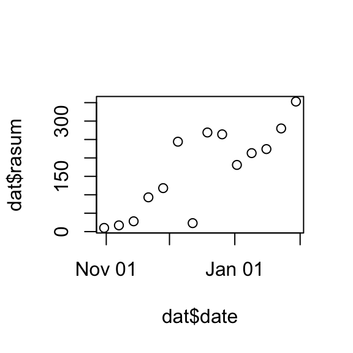

```r
dates <- unique(farmers$date)
rasum <- sapply(dates, function(x) {
  sum(farmers[farmers$date == x, "ra"])
})
dat <- cbind.data.frame("date" = as.Date(dates), rasum)

# base
plot(dat$date, dat$rasum)
```

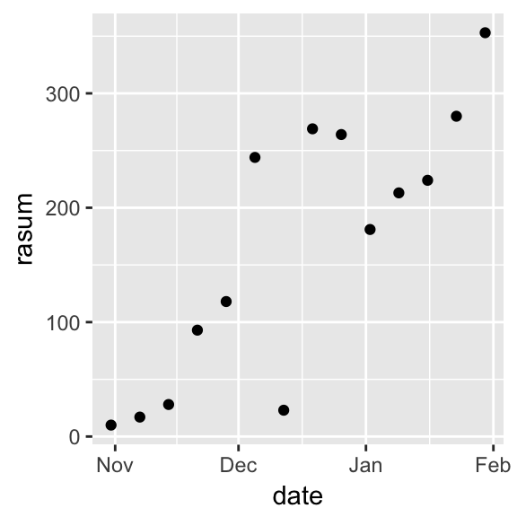

```r
# ggplot
library(ggplot2)
p <- ggplot(dat) + aes(x = date, y = rasum) + geom_point()
p
```

# The answer

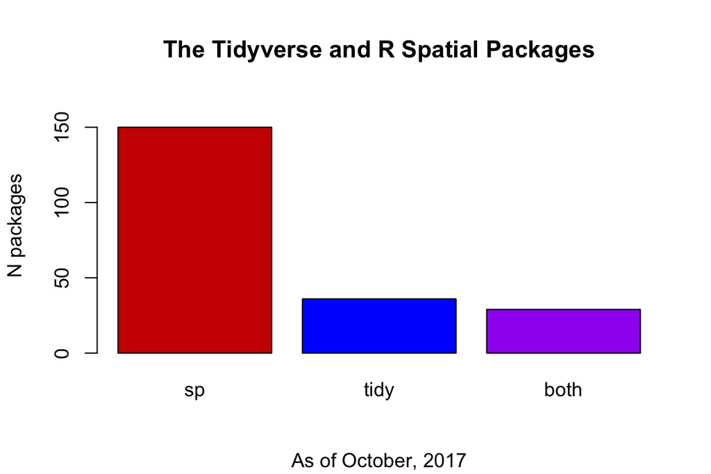

# Base plotting 1

Formula argument versus x, y arguments

```r
plot(rasum ~ date, data = dat)
plot(x = dat$date, y = dat$rasum)
plot(dat$rasum, xaxt = "n")
axis(1, at = 1:length(1:length(dat$rasum)),
     labels = letters[1:length(dat$rasum)])
```

Embellish - your existing plot

```r
quartz(height = 7, width = 7)
plot(x = dat$date, y = dat$rasum, xlab = "date",
     ylab = "ra total", pch = 20, col = "blue", cex = 2,
     las = 2)  # an extra step--rotate axis values
```

# Bonus base plots

A few that weren’t shown in class

Custom plotting - use axis to place labels that are different than the ones that actually make up your x-axis

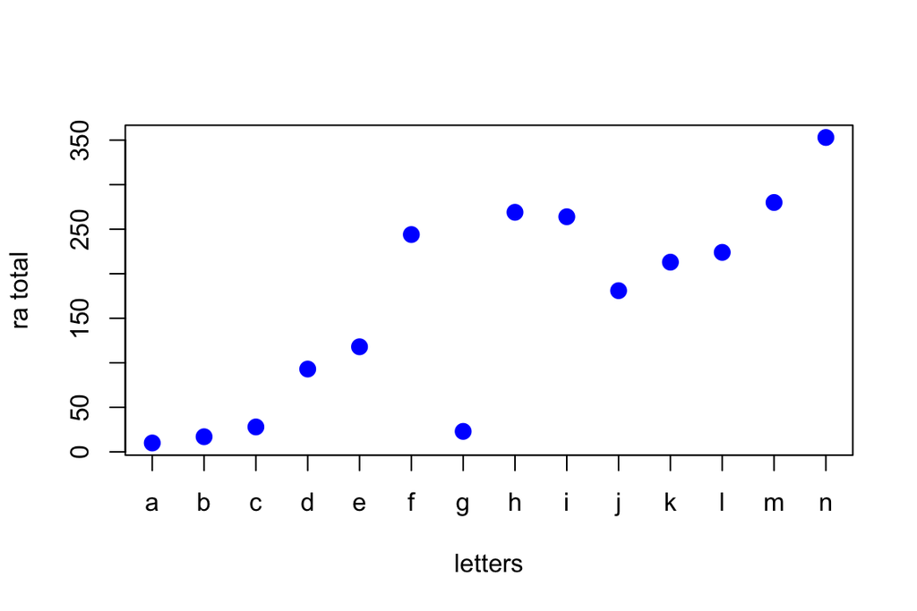

```r
plot(x = dat$date, y = dat$rasum, xlab = "letters",
     ylab = "ra total", pch = 20, col = "blue", cex = 2,
     xaxt = "n")  # don't display x-axis
axis(1, at = dat$date, labels = letters[1:nrow(dat)])
```

Plotting with a single variable. Note that without a y value given, the value passed to x actually gets put on the y axis, plotted against a dummy index on the x axis, which is `1:length(value you are passing to x)` – in this case it is `1:length(dat$rasum)`, or, more simply, `1:nrow(dat)`, since the number of rows in (`nrow(dat)`) is equal to the length of each vector bound together in `dat`, e.g. `length(dat$rasum)`, `length(dat$date)`, etc.

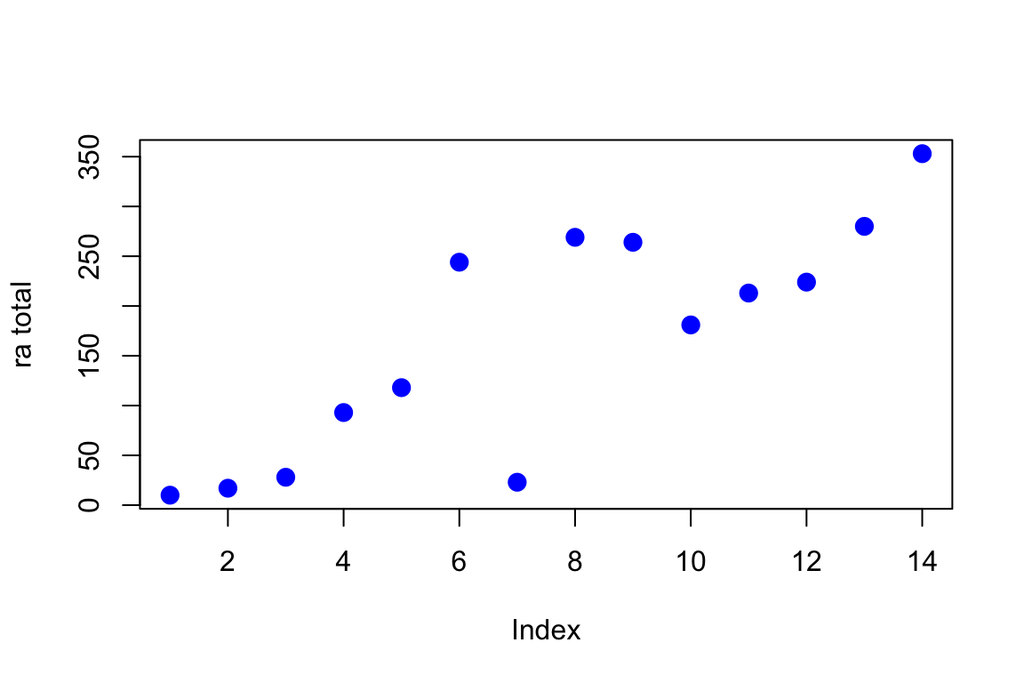

```r
plot(x = dat$rasum, ylab = "ra total", pch = 20, col = "blue", cex = 2)
```

Here is a place where using the `axis` function can be particularly useful

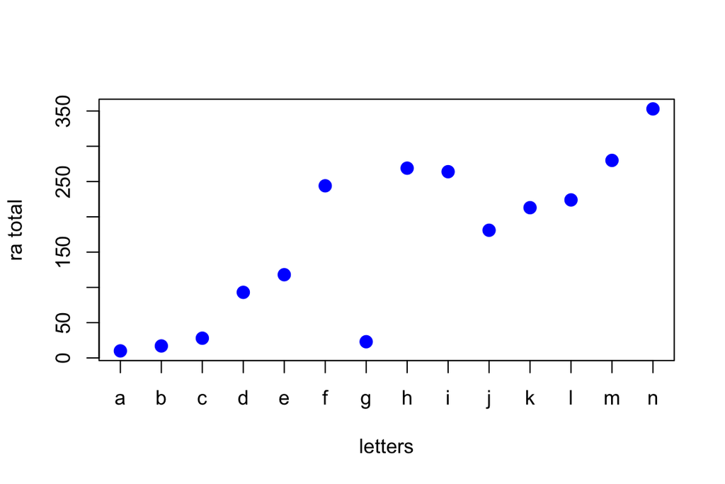

```r
plot(dat$rasum, xlab = "letters",
     ylab = "ra total", pch = 20, col = "blue", cex = 2,
     xaxt = "n")  # don't display x-axis
# axis(1, at = 1:length(dat$rasum), labels = letters[1:1:length(dat$rasum)])
axis(1, at = 1:nrow(dat), labels = letters[1:nrow(dat)])  # same as above
```

# Base Plotting 2

Multi-plots. Side by side.

First, take 5 minutes to make this dataset from `farmers`. Call it `farmers2`. Sum the date-wise values of “pl”, “ra”, and “mm” variables, using `sapply`, and the unique dates to split them (remember the `dates` vector we made in previous classes, using the `unique` function).

(Also remember that the code is available to take a peak at it in the .Rmd file)

```
##          date  pl  ra   mm
## 1  2016-10-31   3  10  205
## 2  2016-11-07  12  17  341
## 3  2016-11-14  12  28  579
## 4  2016-11-21  45  93 1864
## 5  2016-11-28  58 118 2405
## 6  2016-12-05 118 244 5028
## 7  2016-12-12  10  23  480
## 8  2016-12-19 141 269 5449
## 9  2016-12-26 137 264 5340
## 10 2017-01-02  90 181 3591
## 11 2017-01-09  89 213 4288
## 12 2017-01-16 111 224 4478
## 13 2017-01-23 144 280 5482
## 14 2017-01-30 166 353 7064
```

```
## 'data.frame':    14 obs. of  4 variables:
##  $ date: Date, format: "2016-10-31" "2016-11-07" ...
##  $ pl  : num  3 12 12 45 58 118 10 141 137 90 ...
##  $ ra  : num  10 17 28 93 118 244 23 269 264 181 ...
##  $ mm  : num  205 341 579 1864 2405 ...
```

Next, make three plots, one each for column “pl”, “ra”, “mm” as y, with date as x. Start *without* a for loop

# Base plotting 3

Now we’ll do the previous, but using a `for` loop. Also be sure to ask me about controlling figure margins.

Start simply, to just get this. This is not very flexible because we can only change the value of column value with each iteration of the `for` loop.

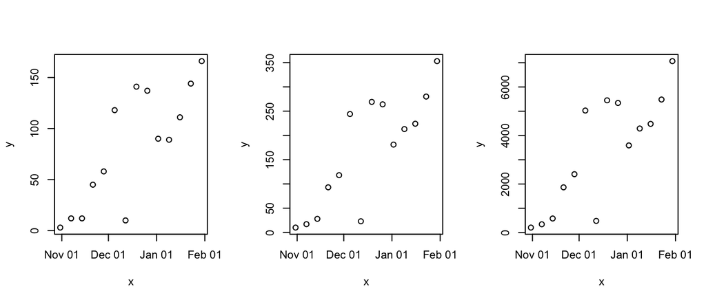

```r
par(mfrow = c(1, 3))
for(i in c("pl", "ra", "mm")) {
  x <- farmers2$date
  y <- farmers2[, i]
  plot(x, y)
}
```

And then this. Note that in this case, by changing the `i` value to an index number, we can change the values for column names, colors, and y axis labels with each iteration of the `for` loop.

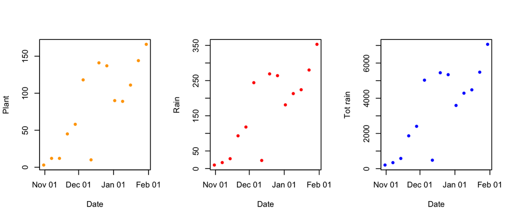

```r
inms <- c("pl", "ra", "mm")
cols <- c("orange", "red", "blue")
ynms <- c("Plant", "Rain", "Tot rain")
par(mfrow = c(1, 3))
for(i in 1:length(inms)) {  # i = 2
  x <- farmers2$date
  y <- farmers2[, inms[i]]
  plot(x, y, pch = 20, col = cols[i], xlab = "Date",
       ylab = ynms[i])
}
```

# Base plotting 4

Do the previous, but instead of xy plot, I want a three-panel histogram of “pl”, “ra”, “mm”, with the the bar colors respectively orange, red, blue.

Here’s a single one to get started

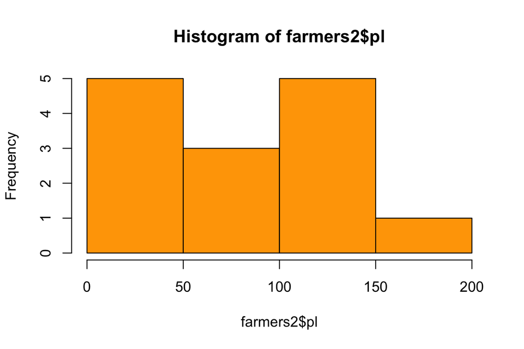

```r
hist(farmers2$pl, col = "orange")
```

# Regressions, including fitted predicted results

Let’s fit a regression between N farmers planting per date, and the total rainfall.

```r
pl_lm <- lm(pl ~ mm, data = farmers2)
# summary(pl_lm)
# coef(pl_lm)
```

And plot the results, three ways

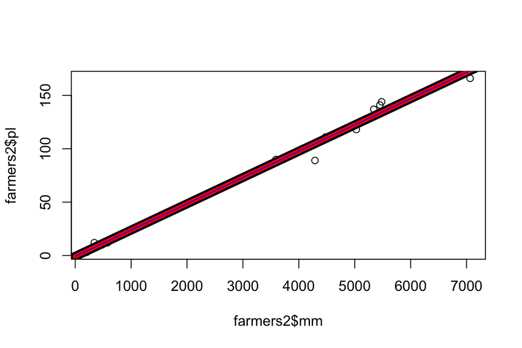

```r
plot(farmers2$mm, farmers2$pl)  # base plot

# method 1 - the abline function
abline(pl_lm, lwd = 10)

# method 2 - the predict function
dummy <- seq(0, 7100, 100)  # first, dummy x value data
method1_predict <- predict(pl_lm, newdata = data.frame("mm" = dummy))
lines(dummy, method1_predict, lwd = 5, col = "red")

# method 3 - manually, using coefficients from linear model
cfs <- coef(pl_lm)  # coefficients
manual_predict <- cfs[1] + cfs[2] * dummy  # predict by hand using coeff.
lines(dummy, manual_predict, col = "blue1", lwd = 1)
```

# Answers to previous exercises

### `lapply`/`sapply` and `colSums`

Two possible interpretations, starting with this, the column sums for all farmers whose IDs match those values.

```r
farmers$date <- as.Date(farmers$date)
farmers <- farmers[order(farmers$date), ]  # reorder farmers by date
dates <- unique(farmers$date)  # unique dates

# interpretation 1: grep
colSums(farmers[grep("8424|166f|99f9", farmers$uuid), c("pl", "ra", "mm")])

# interpretation 2the column sums for the farmer matches to each id
t(sapply(c("8424", "166f", "99f9"), function(x) {
  dat <- farmers[grep(x, farmers$uuid), c("pl", "ra", "mm")]
  colSums(dat)
}))
```

### write.csv

```r
write.csv(farmer_out, file = "~/Desktop/farmer_out.csv")  # easiest
write.csv(farmer_out, file = "~/Desktop/farmer_out.csv",
          row.names = FALSE)  # no row names

# recreate and then append to same csv
write.csv(farmer_out, file = "~/Desktop/farmer_out.csv")
write.table(farmer_out, file = "~/Desktop/farmer_out.csv", append = TRUE,
            sep = ",", col.names = FALSE)  # use write.table to append

# save as R data file, using multiple possible extensions
save(farmer_out, file = "~/Desktop/farmer_out.rda")  # common
rm(list = ls())
load("~/Desktop/farmer_out.rda")
save(farmer_out, file = "~/Desktop/farmer_out.Rdata")
load("~/Desktop/farmer_out.Rdata")  # common
save(farmer_out, file = "~/Desktop/farmer_out.rd")
load("~/Desktop/farmer_out.rd")  # don't use this extension!
```